# Previsão de Votação de Deputados

Previsão de votação de deputados Tutorial utilizado baseado no [Regularized Linear Models](https://www.kaggle.com/code/apapiu/regularized-linear-models/notebook)

```python
%matplotlib inline

import pandas as pd
import matplotlib
import matplotlib.pyplot as plt
import numpy as np
plt.style.use('seaborn-whitegrid')
```

Atributos e descrições:

"sequencial_candidato" :(character) id do candidato

"nome": (character)

"uf": (character)

"partido": (character)

"quantidade_doacoes": (integer)

"quantidade_doadores": (integer) número de doadores diferentes

"total_receita": (double) soma em R$ das doações

"media_receita": (double) média das doações

"recursos_de_outros_candidatos/comites": (double) quantia em R$ das doações provenientes de outros candidatos ou comite partidário

"recursos_de_pessoas_fisicas": (double) quantia em R$ das doações provenientes de outros CPFs

"recursos_de_pessoas_juridicas": (double) quantia em R$ das doações provenientes de outros CNPJ

"recursos_proprios": (double) quantia em R$ das doações provenientes do próprio candidato

"recursos_de_partido_politico": (double) quantia em R$ das doações provenientes do partido político do candidato

"votos": (integer) variável alvo. Se refere ao número de votos na campanha de 2006 e 2010

"quantidade_despesas": (integer)

"quantidade_fornecedores": (integer) número de fornecedores/despesas diferentes

"total_despesa": (double) soma em R$ das despesas de campanha

"media_despesa": (double) média das despesas de campanha

"cargo": (character)

"Sexo": (character)

"grau": (character) grau de instrução do candidato

"estado_civil": (character)

"ocupacao": (character) ocupação do candidato

```python
eleicoes = pd.read_csv('eleicoes_2006_a_2010.csv')
eleicoes[:5]
```

|  | ano | sequencial_candidato | nome | uf | partido | quantidade_doacoes | quantidade_doadores | total_receita | media_receita | recursos_de_outros_candidatos/comites | ... | quantidade_despesas | quantidade_fornecedores | total_despesa | media_despesa | cargo | sexo | grau | estado_civil | ocupacao | votos |
| --- | --- | --- | --- | --- | --- | --- | --- | --- | --- | --- | --- | --- | --- | --- | --- | --- | --- | --- | --- | --- | --- |
| 0 | 2006 | 10001 | JOSÉ LUIZ NOGUEIRA DE SOUSA | AP | PT | 6 | 6 | 16600.00 | 2766.666667 | NaN | ... | 14 | 14 | 16583.60 | 1184.542857 | DEPUTADO FEDERAL | MASCULINO | ENSINO MÉDIO COMPLETO | CASADO(A) | VEREADOR | 8579 |
| 1 | 2006 | 10002 | LOIVA DE OLIVEIRA | RO | PT | 13 | 13 | 22826.00 | 1755.846154 | 6625.0 | ... | 24 | 23 | 20325.99 | 883.738696 | DEPUTADO FEDERAL | FEMININO | SUPERIOR COMPLETO | SOLTEIRO(A) | SERVIDOR PÚBLICO ESTADUAL | 2757 |
| 2 | 2006 | 10002 | MARIA DALVA DE SOUZA FIGUEIREDO | AP | PT | 17 | 16 | 148120.80 | 9257.550000 | 2250.0 | ... | 123 | 108 | 146011.70 | 1351.960185 | DEPUTADO FEDERAL | FEMININO | SUPERIOR COMPLETO | VIÚVO(A) | PEDAGOGO | 17428 |
| 3 | 2006 | 10002 | ROMALDO MILANI | MS | PRONA | 6 | 6 | 3001.12 | 500.186667 | NaN | ... | 8 | 8 | 3001.12 | 375.140000 | DEPUTADO FEDERAL | MASCULINO | ENSINO MÉDIO INCOMPLETO | CASADO(A) | MILITAR REFORMADO | 1193 |
| 4 | 2006 | 10003 | ANSELMO DE JESUS ABREU | RO | PT | 48 | 48 | NaN | NaN | NaN | ... | 133 | 120 | 116416.64 | 970.138667 | DEPUTADO FEDERAL | MASCULINO | ENSINO FUNDAMENTAL COMPLETO | CASADO(A) | DEPUTADO | 29401 |

5 rows × 23 columns

Observando os dados

```python
eleicoes.describe().transpose()
```

|  | count | mean | std | min | 25% | 50% | 75% | max |
| --- | --- | --- | --- | --- | --- | --- | --- | --- |
| ano | 7330.0 | 2.008151e+03 | 1.994416e+00 | 2006.00 | 2006.000000 | 2.010000e+03 | 2.010000e+03 | 2.010000e+03 |
| sequencial_candidato | 7330.0 | 9.179127e+10 | 9.924629e+10 | 10001.00 | 10565.000000 | 5.000000e+10 | 1.900000e+11 | 2.700000e+11 |
| quantidade_doacoes | 7330.0 | 2.831010e+01 | 1.186551e+02 | 1.00 | 4.000000 | 9.000000e+00 | 2.400000e+01 | 6.997000e+03 |
| quantidade_doadores | 7330.0 | 2.581746e+01 | 1.036594e+02 | 1.00 | 4.000000 | 8.000000e+00 | 2.200000e+01 | 5.800000e+03 |
| total_receita | 7169.0 | 1.544899e+05 | 3.953880e+05 | 0.00 | 2700.000000 | 1.209578e+04 | 8.929956e+04 | 4.539727e+06 |
| media_receita | 7169.0 | 5.485598e+03 | 1.411653e+04 | 0.00 | 622.857143 | 1.540543e+03 | 4.662500e+03 | 5.001800e+05 |
| recursos_de_outros_candidatos/comites | 4940.0 | 3.002116e+04 | 1.280932e+05 | 2.41 | 1180.000000 | 3.522570e+03 | 1.327550e+04 | 3.664205e+06 |
| recursos_de_pessoas_fisicas | 4647.0 | 3.730931e+04 | 8.215398e+04 | 0.03 | 2000.000000 | 9.000000e+03 | 3.756234e+04 | 1.403049e+06 |
| recursos_de_pessoas_juridicas | 3354.0 | 1.761195e+05 | 3.517541e+05 | 0.00 | 3422.500000 | 2.612000e+04 | 1.755218e+05 | 3.178226e+06 |
| recursos_proprios | 4942.0 | 3.914169e+04 | 1.839980e+05 | 0.00 | 1177.232500 | 5.000000e+03 | 2.027459e+04 | 5.525600e+06 |
| quantidade_despesas | 7330.0 | 1.333398e+02 | 4.168388e+02 | 1.00 | 6.000000 | 2.100000e+01 | 8.300000e+01 | 9.932000e+03 |
| quantidade_fornecedores | 7330.0 | 1.101799e+02 | 3.384930e+02 | 1.00 | 5.000000 | 1.800000e+01 | 7.100000e+01 | 8.359000e+03 |
| total_despesa | 7330.0 | 1.588707e+05 | 3.951814e+05 | 0.00 | 2781.405000 | 1.297986e+04 | 1.006515e+05 | 4.989491e+06 |
| media_despesa | 7330.0 | 1.500034e+03 | 6.363831e+03 | 0.00 | 398.452936 | 7.946782e+02 | 1.564291e+03 | 5.001770e+05 |
| votos | 7330.0 | 2.280617e+04 | 4.810133e+04 | 2.00 | 860.000000 | 3.025000e+03 | 2.027450e+04 | 1.353820e+06 |

Observando a distribuição variáveis

Distribuição de total_despesa:

```
array([[<AxesSubplot:title={'center':'Total de despesas'}>]], dtype=object)
```

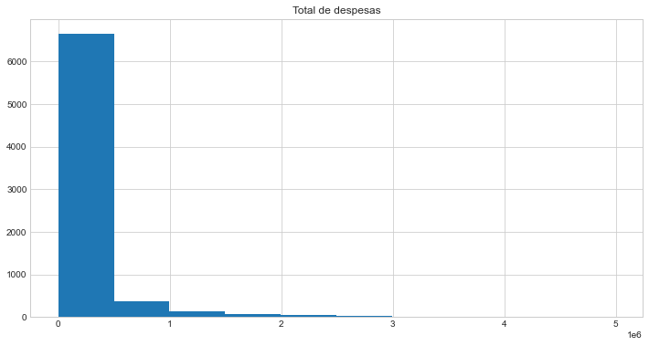

```python
matplotlib.rcParams['figure.figsize'] = (12.0, 6.0)
var = pd.DataFrame({"Total de despesas":eleicoes['total_despesa']})

var.hist()
```

É possível observar que o atributo total_despesa está enviesado para a direita.

Transformação das variáveis do conjunto de dados. Classificando as variáveis em numéricas (quantitativas) e categóricas (qualitativas).

Variáveis numéricas ou quantitativas: recursos_proprios quantidade_doacoes quantidade_doadores media_receita recursos_de_outros_candidatos/comites recursos_de_pessoas_fisicas recursos_de_pessoas_juridicas quantidade_despesas quantidade_fornecedores total_despesa media_despesa votos total_receita

Variáveis categóricas (ou qualitativas) ano sequencial_candidato nome uf partido cargo sexo grau estado_civil ocupacao

Selecionando as variáveis numéricas:

```python
numeric_features = eleicoes.dtypes[eleicoes.dtypes != "object"].index
eleicoes[numeric_features][:10]
```

|  | ano | sequencial_candidato | quantidade_doacoes | quantidade_doadores | total_receita | media_receita | recursos_de_outros_candidatos/comites | recursos_de_pessoas_fisicas | recursos_de_pessoas_juridicas | recursos_proprios | quantidade_despesas | quantidade_fornecedores | total_despesa | media_despesa | votos |
| --- | --- | --- | --- | --- | --- | --- | --- | --- | --- | --- | --- | --- | --- | --- | --- |
| 0 | 2006 | 10001 | 6 | 6 | 16600.00 | 2766.666667 | NaN | 9000.0 | 6300.00 | 1300.00 | 14 | 14 | 16583.60 | 1184.542857 | 8579 |
| 1 | 2006 | 10002 | 13 | 13 | 22826.00 | 1755.846154 | 6625.0 | 15000.0 | 1000.00 | 201.00 | 24 | 23 | 20325.99 | 883.738696 | 2757 |
| 2 | 2006 | 10002 | 17 | 16 | 148120.80 | 9257.550000 | 2250.0 | 34150.0 | 62220.80 | 59500.00 | 123 | 108 | 146011.70 | 1351.960185 | 17428 |
| 3 | 2006 | 10002 | 6 | 6 | 3001.12 | 500.186667 | NaN | 1150.0 | 1101.12 | 750.00 | 8 | 8 | 3001.12 | 375.140000 | 1193 |
| 4 | 2006 | 10003 | 48 | 48 | NaN | NaN | NaN | 50878.0 | NaN | 68942.00 | 133 | 120 | 116416.64 | 970.138667 | 29401 |
| 5 | 2006 | 10003 | 6 | 6 | 1771.21 | 295.201667 | NaN | NaN | NaN | 1771.21 | 9 | 9 | 1771.21 | 196.801111 | 1822 |
| 6 | 2006 | 10003 | 14 | 7 | 697.00 | 99.571429 | NaN | 1231.0 | NaN | NaN | 17 | 10 | 696.91 | 69.691000 | 317 |
| 7 | 2006 | 10003 | 2 | 2 | 70000.00 | 35000.000000 | NaN | NaN | NaN | 70000.00 | 332 | 278 | 66016.95 | 237.471043 | 2591 |
| 8 | 2006 | 10004 | 2 | 2 | 6065.00 | 3032.500000 | 6065.0 | NaN | NaN | NaN | 10 | 10 | 6060.42 | 606.042000 | 2551 |
| 9 | 2006 | 10004 | 68 | 65 | 105813.20 | 1627.895385 | 9575.0 | 59143.2 | 26000.00 | 16500.00 | 68 | 67 | 110818.20 | 1654.002985 | 34631 |

Enviesamento das variáveis:

```python
skewed_features = eleicoes[numeric_features].apply(lambda x: x.dropna().skew())
skewed_features
```

```
ano                                      -0.151624
sequencial_candidato                      0.447496
quantidade_doacoes                       39.982260
quantidade_doadores                      37.541762
total_receita                             4.599988
media_receita                            12.105833
recursos_de_outros_candidatos/comites    13.892631
recursos_de_pessoas_fisicas               6.800271
recursos_de_pessoas_juridicas             3.431190
recursos_proprios                        15.782559
quantidade_despesas                       8.546077
quantidade_fornecedores                   8.424869
total_despesa                             4.534959
media_despesa                            66.379222
votos                                     6.669571
dtype: float64
```

```python
skewed_features = skewed_features[skewed_features > 0.75]
skewed_features

skewed_features = skewed_features.index

eleicoes[skewed_features] = np.log1p(eleicoes[skewed_features])
eleicoes[numeric_features][:5]
```

|  | ano | sequencial_candidato | quantidade_doacoes | quantidade_doadores | total_receita | media_receita | recursos_de_outros_candidatos/comites | recursos_de_pessoas_fisicas | recursos_de_pessoas_juridicas | recursos_proprios | quantidade_despesas | quantidade_fornecedores | total_despesa | media_despesa | votos |
| --- | --- | --- | --- | --- | --- | --- | --- | --- | --- | --- | --- | --- | --- | --- | --- |
| 0 | 2006 | 10001 | 1.945910 | 1.945910 | 9.717218 | 7.925760 | NaN | 9.105091 | 8.748464 | 7.170888 | 2.708050 | 2.708050 | 9.716230 | 7.077956 | 9.057189 |
| 1 | 2006 | 10002 | 2.639057 | 2.639057 | 10.035699 | 7.471276 | 8.798757 | 9.615872 | 6.908755 | 5.308268 | 3.218876 | 3.178054 | 9.919705 | 6.785292 | 7.922261 |
| 2 | 2006 | 10002 | 2.890372 | 2.833213 | 11.905790 | 9.133303 | 7.719130 | 10.438547 | 11.038461 | 10.993748 | 4.820282 | 4.691348 | 11.891449 | 7.210050 | 9.765891 |
| 3 | 2006 | 10002 | 1.945910 | 1.945910 | 8.007074 | 6.216979 | NaN | 7.048386 | 7.004991 | 6.621406 | 2.197225 | 2.197225 | 8.007074 | 5.929961 | 7.085064 |
| 4 | 2006 | 10003 | 3.891820 | 3.891820 | NaN | NaN | NaN | 10.837206 | NaN | 11.141035 | 4.897840 | 4.795791 | 11.664939 | 6.878469 | 10.288818 |

Selecionando as variáveis categóricas:

```python
eleicoes.shape #quantidade de linhas e colunas
```

```
(7330, 23)
```

```python
eleicoes = pd.get_dummies(eleicoes) #transformando atributos
eleicoes.shape
```

```
(7330, 7038)
```

Tratando valores NaN: preenchendo com as médias de valores de cada coluna

```python
eleicoes_mean = eleicoes.fillna(eleicoes.mean())
```

Separação dos dados

```python
eleicoes = eleicoes_mean
n = int(7330/2)
sample = eleicoes.sample(n=n)
eleicoes.shape

sample = sample.drop(['sequencial_candidato', 'total_despesa', 'media_despesa'], axis=1)
```

```python
sample[(sample.ano==2006)].shape # para 2006
```

```
(1702, 7035)
```

```python
sample[(sample.ano==2010)].shape # para 2010
```

```
(1963, 7035)
```

```python
train = sample[:int(n/2)]
test = sample[int(n/2):]
```

Criando vetores

```python
#usando sklearn
x_train = train.drop('votos', axis=1)
y_train = train['votos']

x_test = test.drop('votos', axis=1)
y_test = test['votos']

x_all = sample.drop('votos', axis=1)
y_all = sample['votos']
```

Resíduos X Predições

```python
def vis_residuos_vs_predicoes(y_pred, y_real, titulo):
    matplotlib.rcParams['figure.figsize'] = (6.0, 6.0)
    predicoes = pd.DataFrame({"predicoes":y_pred, "valor_real":y_real})
    predicoes["residuos"] = predicoes["valor_real"] - predicoes["predicoes"]
    predicoes.plot(x = "predicoes", y = "residuos",kind = "scatter")
    plt.title(titulo)
```

1) Regressão sem regularização

```python
from sklearn.linear_model import LinearRegression
from sklearn.metrics import mean_squared_error, r2_score, explained_variance_score, median_absolute_error
reg = LinearRegression()
reg.fit(x_train, y_train)
```

```
LinearRegression()
```

Predição para o conjunto de teste

```python
y_pred_model_reg = reg.predict(x_test)
y_pred_model_reg
```

```
array([ -6.29116505,  -2.77154276, -13.83737599, ...,  -0.06053642,
        18.09656491,  33.36844431])
```

Métricas:

```python
reg.coef_ #coeficiente para os atributos
```

```
array([ -2.5350213 ,  25.02249165, -15.23887291, ..., -27.92054868,
         7.18533253,   0.        ])
```

```python
mse = mean_squared_error(y_test, y_pred_model_reg) #média do quadrado do erro
mse
```

```
258.3183719868154
```

```python
np.sqrt(mse)
```

```
16.07228583577381
```

```python
r2_score(y_test, y_pred_model_reg) #r2_score
```

```
-63.44692343496531
```

Resíduos X Previsões

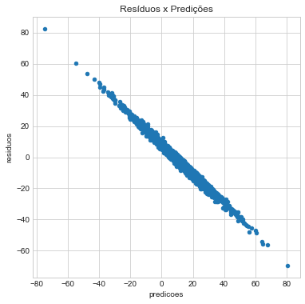

```python
vis_residuos_vs_predicoes(y_pred_model_reg, y_test, "Resíduos x Predições")
```

Os valores estão muito próximos formando uma reta, o que pode indicar um super ajuste.

Regularização Ridge e Lasso

```python
from sklearn.linear_model import Ridge, RidgeCV, ElasticNet, LassoCV, LassoLarsCV
from sklearn.model_selection import cross_val_score
```

```python
#métricas pra validação cruzada
def calc_rmse(model, cv): #RMSE
    rmse = np.sqrt(-cross_val_score(model, x_all, y_all, scoring="neg_mean_squared_error", cv=cv))
    print("RMSE is: {0} ".format(rmse))
    return rmse

def calc_r2(model, cv): #r2_score
    r2 = np.sqrt(cross_val_score(model, x_all, y_all, scoring="r2", cv=cv))
    print("R² is: {0} ".format(r2))
    return r2

def calc_variance(model, cv): #variancia
    explained_variance = np.sqrt(cross_val_score(model, x_train, y_train, scoring="explained_variance", cv=cv))
    print("Variance is: {0} ".format(explained_variance))
    return explained_variance

def gerar_vis_validacao(measures, alphas, title_measure): #visualização
    matplotlib.rcParams['figure.figsize'] = (8.0, 6.0)
    data = pd.Series(measures, index=alphas)
    data.plot(title = "Validação")
    plt.xlabel("alpha")
    plt.ylabel(title_measure)
```

Regressão Ridge

```python
alphas = [0.2, 0.5, 2, 5, 7]
cv = 5
```

```python
ridge_rmse = [calc_rmse(Ridge(alpha=alpha), cv).mean()
            for alpha in alphas]

ridge_rmse
```

```
RMSE is: [0.97850064 0.89863377 0.969167   0.9719361  0.90842349]
RMSE is: [0.97593583 0.8953908  0.96200012 0.968288   0.90352419]
RMSE is: [0.97504828 0.89383645 0.95754083 0.96100184 0.89943963]
RMSE is: [0.97603142 0.89472794 0.95744823 0.95763895 0.89747321]
RMSE is: [0.97666897 0.89571723 0.95781523 0.95680337 0.89664961]
```

```
[0.945332200683929,
 0.9410277875883735,
 0.9373734052770877,
 0.9366639485979495,
 0.9367308823545557]
```

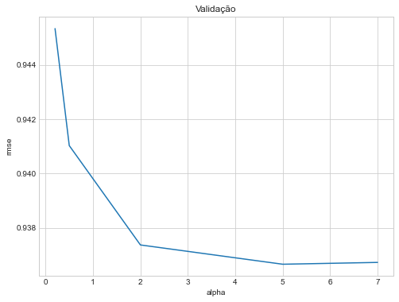

```python
gerar_vis_validacao(ridge_rmse, alphas, "rmse")
```

```python
ridge_r2 = [calc_r2(Ridge(alpha=alpha), cv).mean()
            for alpha in alphas]

ridge_r2
```

```
R² is: [0.86754077 0.89056386 0.87864553 0.87098377 0.88725922]
R² is: [0.86828688 0.89140035 0.88055511 0.87202144 0.88854812]
R² is: [0.86854446 0.89179992 0.88173405 0.87407859 0.88961594]
R² is: [0.86825912 0.89157086 0.88175845 0.87502119 0.89012783]
R² is: [0.86807387 0.89131632 0.88166171 0.87525474 0.89034181]
```

```
[0.8789986302059912,
 0.88016237913425,
 0.8811545913982382,
 0.8813474907872862,
 0.8813296885372541]
```

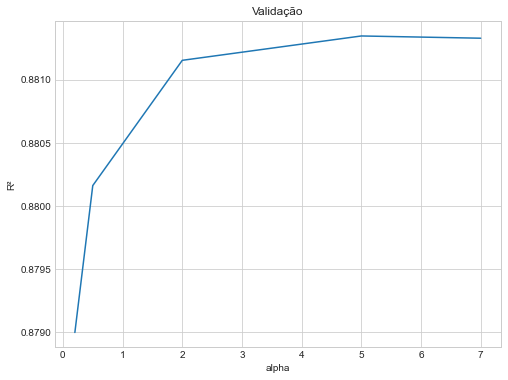

```python
gerar_vis_validacao(ridge_r2, alphas, "R²")
```

```python
ridge_variance = [calc_variance(Ridge(alpha=alpha), cv).mean()
            for alpha in alphas]

ridge_variance
```

```
Variance is: [0.85318301 0.87485483 0.88791835 0.87459737 0.85822499]
Variance is: [0.85372365 0.87584586 0.88931145 0.87485333 0.85951049]
Variance is: [0.85424852 0.87776531 0.89184959 0.87501226 0.86132907]
Variance is: [0.85383824 0.87914982 0.89335956 0.87462051 0.86214148]
Variance is: [0.85341292 0.87954792 0.89367941 0.87418507 0.86230673]
```

```
[0.8697557074843392,
 0.8706489553436436,
 0.8720409481971678,
 0.8726219216980363,
 0.8726264082632408]
```

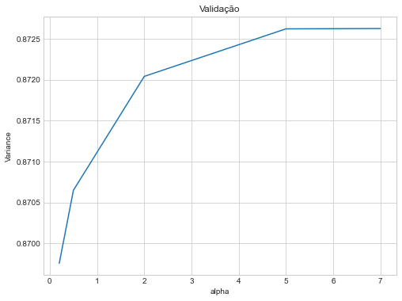

```python
gerar_vis_validacao(ridge_variance, alphas, "Variance")
```

```python
model_ridge = Ridge(alpha=2)
model_ridge.fit(x_train, y_train)

y_pred_model_ridge = model_ridge.predict(x_test)
y_pred_model_ridge

# MSE Ridge
mse_ridge = mean_squared_error(y_test, y_pred_model_ridge)
mse_ridge
np.sqrt(mse)

#R2 Score
r2_score(y_test, y_pred_model_ridge)
```

```
0.7811058463177206
```

Resíduos X Predições (Ridge)

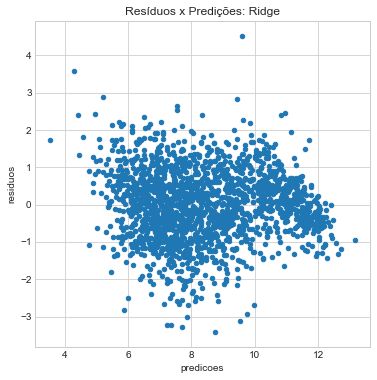

```python
vis_residuos_vs_predicoes(y_pred_model_ridge, y_test, "Resíduos x Predições: Ridge")
```

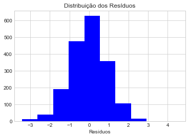

```python
matplotlib.rcParams['figure.figsize'] = (6.0, 4.0)
residuos = y_test - y_pred_model_ridge
residuos.hist(color = "blue")
plt.xlabel('Resíduos')
plt.title('Distribuição dos Resíduos')
```

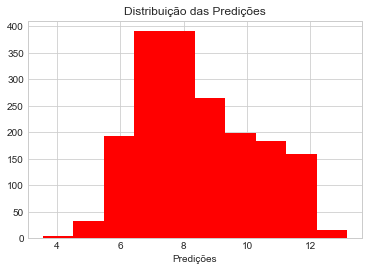

```python
matplotlib.rcParams['figure.figsize'] = (6.0, 4.0)
pd.Series(y_pred_model_ridge).hist(color = "Red")
plt.xlabel('Predições')
plt.title('Distribuição das Predições')
```

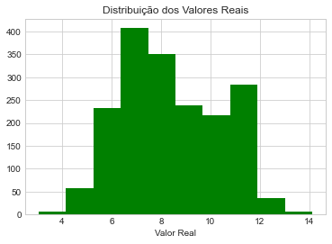

```python
matplotlib.rcParams['figure.figsize'] = (6.0, 4.0)
pd.Series(y_test).hist(color = "green")
plt.xlabel('Valor Real')
plt.title('Distribuição dos Valores Reais')
```

Regressão Lasso

```python
model_lasso = LassoCV(alphas=[1, 0.1, 0.001, 0.005], max_iter=3000).fit(x_train, y_train)
model_lasso
```

```
LassoCV(alphas=[1, 0.1, 0.001, 0.005], max_iter=3000)
```

```python
model_lasso.alpha_
```

```
0.001
```

```python
#RMSE
def calc_rmse_lasso(model, cv):
    rmse = np.sqrt(-cross_val_score(model, x_train, y_train, scoring="neg_mean_squared_error", cv=cv))
    print("RMSE is: {0} ".format(rmse))
    return rmse

rmse_lasso = calc_rmse_lasso(model_lasso, 3).mean()
rmse_lasso
```

```
RMSE is: [1.01613052 0.89976147 0.98105202]
```

```
0.9656480034587466
```

```python
y_pred_model_lasso = model_lasso.predict(x_test)
y_pred_model_lasso
```

```
array([ 8.14843602,  8.69553594,  8.08119178, ...,  8.60961924,
       11.06117973, 11.69081857])
```

```python
#r2 score
model_lasso.score(x_test, y_test)

coef = pd.Series(model_lasso.coef_, index = x_train.columns)
print("Foram selecionadas " + str(sum(coef != 0)) + " variáveis e rejeitadas " +
      str(sum(coef == 0)) + " variáveis")
```

```
Foram selecionadas 192 variáveis e rejeitadas 6842 variáveis
```

```python
descricao_coeficientes = pd.concat([coef.sort_values().head(10),
                                   coef.sort_values().tail(15)])
descricao_coeficientes
```

```
nome_EDILBERTO AFONSO DE MORAES JUNIOR                     -2.208980
nome_DERMERVAL DA CUNHA SILVA NETO                         -2.149001
nome_JOCEANE SILVA MARQUES RIBEIRO                         -1.688205
ocupacao_ESTETICISTA                                       -1.269212
nome_CARLOS ANDRÉ CAVALCANTI FERREIRA                      -1.207400
nome_GERSON BENEDICTO                                      -1.200375
nome_MARCELO OLIVEIRA                                      -1.138374
nome_MARIA APARECIDA DUARTE                                -0.966498
nome_JOSÉ RICARDO SILVEIRA MARQUES                         -0.868876
nome_ELISETE MENIN ARNOLD                                  -0.796055
ocupacao_MÚSICO                                             0.637406
nome_ANA FLAVIA BOTELHO RODRIGUES                           0.646247
ocupacao_VEREADOR                                           0.670553
uf_MA                                                       0.702865
ocupacao_CANTOR E COMPOSITOR                                0.718121
ocupacao_SACERDOTE OU MEMBRO DE ORDEM OU SEITA RELIGIOSA    0.722050
uf_CE                                                       0.723571
ocupacao_DEPUTADO                                           0.742067
nome_PAULO SALIM MALUF                                      0.860368
nome_JAIR MESSIAS BOLSONARO                                 1.156189
ocupacao_ATLETA PROFISSIONAL E TÉCNICO EM DESPORTOS         1.175049
nome_LUIZA ERUNDINA DE SOUSA                                1.450742
nome_IOLANDA KEIKO MIASHIRO OTA                             1.588730
nome_ENEAS FERREIRA CARNEIRO                                2.821354
nome_CLODOVIL HERNANDES                                     3.317236
dtype: float64
```

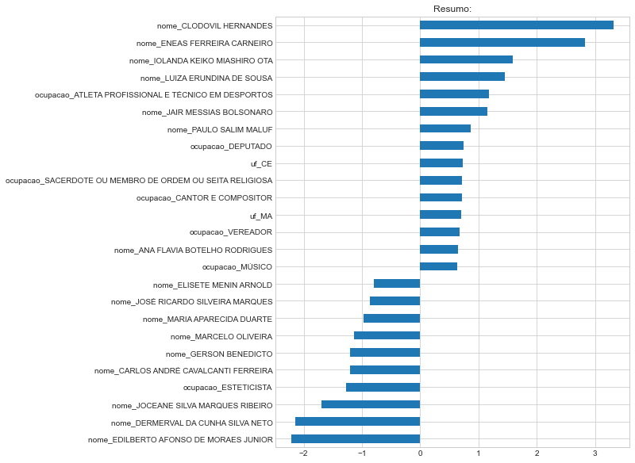

```python
matplotlib.rcParams['figure.figsize'] = (8.0, 10.0)
descricao_coeficientes.plot(kind= 'barh')
plt.title("Resumo:")
```

Predições X Resíduos (Regressão Lasso)

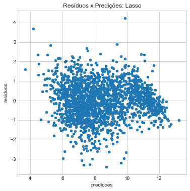

```python
vis_residuos_vs_predicoes(y_pred_model_lasso, y_test, "Resíduos x Predições: Lasso")
```

Usando o KNN

```python
from sklearn.neighbors import KNeighborsRegressor

knn_model = KNeighborsRegressor(n_neighbors=3).fit(x_train, y_train)
y_pred_model_knn = knn_model.predict(x_test)
y_pred_model_knn
```

```
array([ 7.61988148,  7.9620161 ,  8.24612339, ...,  8.60532122,
       10.52975272, 11.34965227])
```

```python
#r2 score
r2_score(y_test, y_pred_model_knn)
```

```
0.7211515314894759
```

```python
#mse
mse_knn = mean_squared_error(y_test, y_pred_model_knn)
np.sqrt(mse_knn)
```

```
1.0572085928188977
```

Predições Vs Resíduos (KNN)

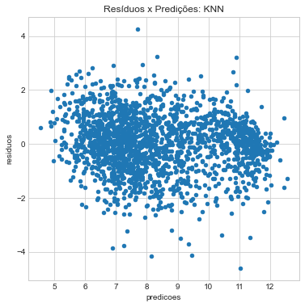

```python
vis_residuos_vs_predicoes(y_pred_model_knn, y_test, "Resíduos x Predições: KNN")
```

Predições Vs Resíduos nos modelos

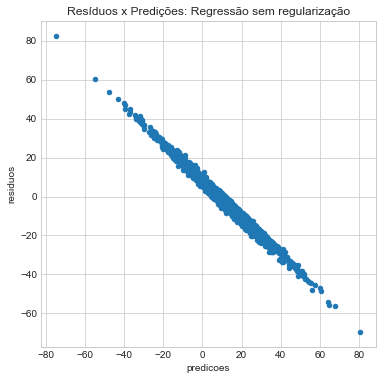

```python
#Regressão sem regulariação
vis_residuos_vs_predicoes(y_pred_model_reg, y_test, "Resíduos x Predições: Regressão sem regularização")
```

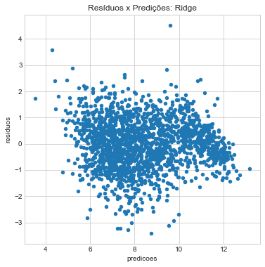

```python
#Ridge
vis_residuos_vs_predicoes(y_pred_model_ridge, y_test, "Resíduos x Predições: Ridge")
```

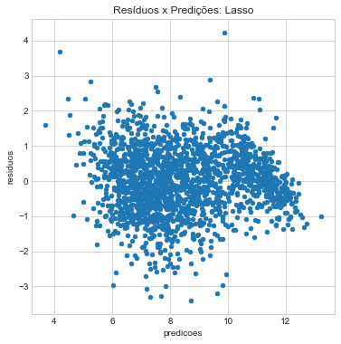

```python
#Lasso
vis_residuos_vs_predicoes(y_pred_model_lasso, y_test, "Resíduos x Predições: Lasso")
```

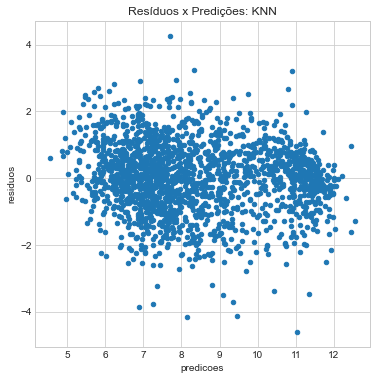

```python
#KNN
vis_residuos_vs_predicoes(y_pred_model_knn, y_test, "Resíduos x Predições: KNN")
```

UTILIZANDO DADOS DAS ELEOÇÕES DE 2014

```python
eleicoes_2014 = pd.read_csv('eleicoes_2014.csv')
eleicoes_2014[:10]
```

|  | ano | sq_candidato | nome_candidato | sigla_uf | sigla_partido | qtd_doacoes | qtd_doadores | total_receita | media_receita | recursos de outros candidatos/comitês | ... | qtd_despesas | qtd_fornecedores | total_despesa | media_despesa | descricao_cargo | sexo | grau_instrucao | estado_civil | descricao_ocupacao | votos |
| --- | --- | --- | --- | --- | --- | --- | --- | --- | --- | --- | --- | --- | --- | --- | --- | --- | --- | --- | --- | --- | --- |
| 0 | 2014 | 10000000135 | EMERSON DA SILVA SANTOS | AC | PSOL | 3 | 3 | 1580.00 | 526.666667 | NaN | ... | 3 | 3 | 1580.00 | 526.666667 | DEPUTADO FEDERAL | MASCULINO | ENSINO MÉDIO COMPLETO | SOLTEIRO(A) | CORRETOR DE IMÓVEIS, SEGUROS, TÍTULOS E VALORES | 37 |
| 1 | 2014 | 10000000142 | GERALDO SILVA DOS SANTOS | AC | PSOL | 5 | 5 | 3180.00 | 636.000000 | NaN | ... | 6 | 5 | 3130.02 | 626.004000 | DEPUTADO FEDERAL | MASCULINO | SUPERIOR COMPLETO | SOLTEIRO(A) | VIGILANTE | 383 |
| 2 | 2014 | 10000000158 | CARLOS CESAR CORREIA DE MESSIAS | AC | PSB | 40 | 38 | 333293.13 | 8770.871842 | 1923.07 | ... | 145 | 139 | 326869.78 | 2351.581151 | DEPUTADO FEDERAL | MASCULINO | ENSINO FUNDAMENTAL INCOMPLETO | CASADO(A) | OUTROS | 26448 |
| 3 | 2014 | 10000000161 | IDESIO LUIS FRANKE | AC | PT | 29 | 29 | 156719.32 | 5404.114483 | 39122.32 | ... | 136 | 121 | 241016.07 | 1991.868347 | DEPUTADO FEDERAL | MASCULINO | SUPERIOR COMPLETO | CASADO(A) | AGRÔNOMO | 9896 |
| 4 | 2014 | 10000000163 | LEONARDO CUNHA DE BRITO | AC | PT | 160 | 146 | 711083.00 | 4870.431507 | 10000.00 | ... | 518 | 354 | 567401.15 | 1602.828107 | DEPUTADO FEDERAL | MASCULINO | SUPERIOR COMPLETO | CASADO(A) | ADVOGADO | 20876 |
| 5 | 2014 | 10000000164 | MARCELO FEITOSA DE ARAÚJO | AC | PT | 4 | 3 | 23000.00 | 7666.666667 | 20000.00 | ... | 12 | 12 | 29950.00 | 2495.833333 | DEPUTADO FEDERAL | MASCULINO | ENSINO MÉDIO COMPLETO | SOLTEIRO(A) | BOMBEIRO MILITAR | 1025 |
| 6 | 2014 | 10000000166 | RAIMUNDO ANGELIM VASCONCELOS | AC | PT | 48 | 48 | 405006.67 | 8437.638958 | 24166.67 | ... | 336 | 281 | 345879.40 | 1230.887544 | DEPUTADO FEDERAL | MASCULINO | SUPERIOR COMPLETO | CASADO(A) | PROFESSOR DE ENSINO SUPERIOR | 39844 |
| 7 | 2014 | 10000000168 | RAMAO VIEIRA DE OLIVEIRA | AC | PROS | 3 | 3 | 150000.00 | 50000.000000 | 150000.00 | ... | 56 | 53 | 148903.95 | 2809.508491 | DEPUTADO FEDERAL | MASCULINO | ENSINO MÉDIO INCOMPLETO | CASADO(A) | EMPRESÁRIO | 1994 |
| 8 | 2014 | 10000000169 | REGINA AMELIA D ALENCAR LINO | AC | PTB | 15 | 13 | 460300.00 | 35407.692308 | 100000.00 | ... | 177 | 170 | 554900.36 | 3264.119765 | DEPUTADO FEDERAL | FEMININO | SUPERIOR COMPLETO | DIVORCIADO(A) | ASSISTENTE SOCIAL | 3842 |
| 9 | 2014 | 10000000170 | ROSELI COSTA | AC | PT | 13 | 13 | 66093.33 | 5084.102308 | NaN | ... | 21 | 21 | 66093.33 | 3147.301429 | DEPUTADO FEDERAL | FEMININO | SUPERIOR COMPLETO | CASADO(A) | VEREADOR | 1913 |

10 rows × 23 columns

```python
numeric_features = eleicoes_2014.dtypes[eleicoes_2014.dtypes != "object"].index
skewed_features = eleicoes_2014[numeric_features].apply(lambda x: x.dropna().skew())
skewed_features = skewed_features[skewed_features > 0.7]
skewed_features = skewed_features.index
```

```python
eleicoes_2014[skewed_features] = np.log1p(eleicoes_2014[skewed_features])
eleicoes_2014 = eleicoes_2014.fillna(eleicoes_2014.mean())
eleicoes_2014[numeric_features][:10]
```

|  | ano | sq_candidato | qtd_doacoes | qtd_doadores | total_receita | media_receita | recursos de outros candidatos/comitês | recursos de pessoas físicas | recursos de pessoas jurídicas | recursos próprios | qtd_despesas | qtd_fornecedores | total_despesa | media_despesa | votos |
| --- | --- | --- | --- | --- | --- | --- | --- | --- | --- | --- | --- | --- | --- | --- | --- |
| 0 | 2014 | 10000000135 | 1.386294 | 1.386294 | 7.365813 | 6.268465 | 8.442226 | 7.313887 | 10.039024 | 8.505303 | 1.386294 | 1.386294 | 7.365813 | 6.268465 | 3.637586 |
| 1 | 2014 | 10000000142 | 1.791759 | 1.791759 | 8.064951 | 6.456770 | 8.442226 | 8.039480 | 10.039024 | 8.505303 | 1.945910 | 1.791759 | 8.049114 | 6.440953 | 5.950643 |
| 2 | 2014 | 10000000158 | 3.713572 | 3.663562 | 12.716781 | 9.079305 | 7.562198 | 11.092869 | 11.945818 | 11.652696 | 4.983607 | 4.941642 | 12.697320 | 7.763268 | 10.182974 |
| 3 | 2014 | 10000000161 | 3.401197 | 3.401197 | 11.962218 | 8.595101 | 10.574474 | 11.138739 | 9.741027 | 8.826758 | 4.919981 | 4.804021 | 12.392623 | 7.597330 | 9.199987 |
| 4 | 2014 | 10000000163 | 5.081404 | 4.990433 | 13.474546 | 8.491143 | 9.210440 | 12.757293 | 12.531776 | 11.264477 | 6.251904 | 5.872118 | 13.248824 | 7.380149 | 9.946403 |
| 5 | 2014 | 10000000164 | 1.609438 | 1.386294 | 10.043293 | 8.944768 | 9.903538 | 8.626232 | 8.517393 | 8.987322 | 2.564949 | 2.564949 | 10.307318 | 7.822779 | 6.933423 |
| 6 | 2014 | 10000000166 | 3.891820 | 3.891820 | 12.911661 | 9.040576 | 10.092771 | 11.996592 | 10.239996 | 10.262595 | 5.820083 | 5.641907 | 12.753848 | 7.116303 | 10.592752 |
| 7 | 2014 | 10000000168 | 1.386294 | 1.386294 | 11.918397 | 10.819798 | 11.918397 | 8.626232 | 10.039024 | 8.505303 | 4.043051 | 3.988984 | 11.911063 | 7.941121 | 7.598399 |
| 8 | 2014 | 10000000169 | 2.772589 | 2.639057 | 13.039636 | 10.474713 | 11.512935 | 10.507831 | 12.936036 | 9.071193 | 5.181784 | 5.141664 | 13.226546 | 8.091052 | 8.254009 |
| 9 | 2014 | 10000000170 | 2.639057 | 2.639057 | 11.098838 | 8.534070 | 8.442226 | 10.396994 | 9.816531 | 9.615872 | 3.091042 | 3.091042 | 11.098838 | 8.054618 | 7.556951 |

```python
eleicoes_2014 = pd.get_dummies(eleicoes)
eleicoes_2014 = eleicoes_2014.drop(['sequencial_candidato', 'total_despesa', 'media_despesa'], axis=1)
eleicoes_2014.shape
```

```
(7330, 7035)
```

```python
#Ridge
x = eleicoes_2014.drop('votos', axis=1)
y = eleicoes_2014['votos']

y_pred_model_reg_eleicao_2014 = model_ridge.predict(x)
y_pred_model_reg_eleicao_2014
```

```
array([8.63716882, 7.91321228, 9.59454756, ..., 5.87817727, 6.02595461,
       7.46473983])
```

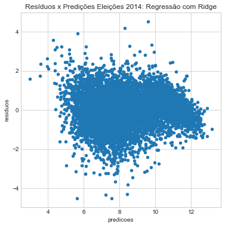

```python
vis_residuos_vs_predicoes(y_pred_model_reg_eleicao_2014, y, "Resíduos x Predições Eleições 2014: Regressão com Ridge")
```

```python
#RSME Ridge
mse_2014 = mean_squared_error(y, y_pred_model_reg_eleicao_2014)
np.sqrt(mse_2014)
```

```
0.8773574394547957
```

```python
#Lasso
y_pred_model_reg_eleicao_2014_lasso = model_lasso.predict(x)
y_pred_model_reg_eleicao_2014_lasso
```

```
array([8.6248586 , 7.90747564, 9.20142861, ..., 6.01272429, 6.34137972,
       7.55720359])
```

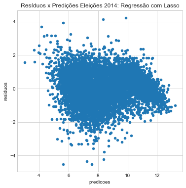

```python
vis_residuos_vs_predicoes(y_pred_model_reg_eleicao_2014_lasso, y, "Resíduos x Predições Eleições 2014: Regressão com Lasso")
```

```python
#RMSE Lasso
mse_2014_lasso = mean_squared_error(y, y_pred_model_reg_eleicao_2014_lasso)
np.sqrt(mse_2014_lasso)
```

```
0.9219252213223885
```